# Car Fuel Economy

MATH 421 final project

## The data

The source is FuelEconomy.gov. The prepared file has 12,381 gasoline and diesel configurations.

A row is a vehicle configuration, such as a model with a particular engine and transmission. It is not a vehicle sale.

Non-plug-in hybrids are included. Electric, plug-in, flexible-fuel, and dual-fuel vehicles are excluded.

## Five different inputs

The dropdown selects a manufacturer. Checkboxes select vehicle groups.

The slider selects model years. Radio buttons select gasoline, diesel, or both.

The numeric input sets the maximum engine size. All five inputs filter the same dataset.

## Dashboard features

Overview shows three value boxes, a findings paragraph, and the yearly MPG plot.

Group Comparisons uses tabs for vehicle groups and manufacturer rankings. Engine and Driving has two scatterplots.

Vehicle Data has a searchable table. About the Data explains the source, cleaning, and limitations.

## Results with all filters open

The 12,381 configurations average 23.3 combined MPG.

Highway MPG is 6.7 higher than city MPG on average. Cars have a median combined MPG of 24, compared with 19 for pickups.

These comparisons give every configuration equal weight. They do not represent the mix of vehicles people bought.

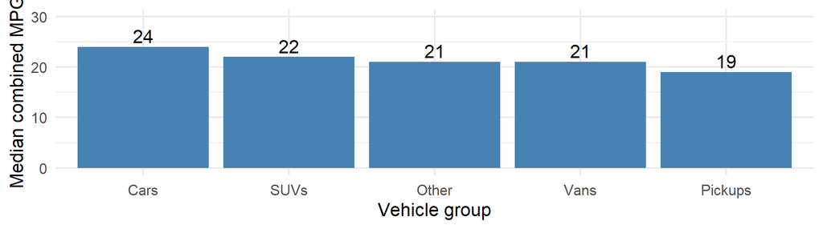

## How the code is organized

Setup loads the packages and reads the prepared CSV once.

The sidebar creates the five inputs. Output chunks create places for plots, values, and the table.

The server chunk uses reactive() to filter the rows. renderPlotly(), renderText(), renderUI(), and renderDT() fill the outputs.

## How the filtering works

```r
filtered <- reactive({
  d <- df %>%
    filter(vehicle_group %in% input$groups,
           year >= input$years[1],
           year <= input$years[2],
           engine_l <= input$engine_max)
  # Manufacturer and fuel filters follow.
})
```

reactive() recalculates when an input changes. Each output calls filtered() so the figures use the same selection.

## Challenges and fixes

MPG and electric MPGe have different meanings. The project focuses on single-fuel gasoline and diesel configurations.

Empty filters can leave no rows. Each plot checks the row count and shows a message instead of an unexplained blank plot.

The live image folder needs a Shiny resource path. The value boxes use value_box() so their numbers can update.

## A simple live demonstration

Start with all filters open and read the summary values.

Choose Toyota, keep only SUVs, choose Gasoline, and set the maximum engine size to 2.5 liters.

Open the comparison tabs and the Vehicle Data page. Search for RAV4. The sidebar filters the full dashboard; table search filters only the table.

## Advice for this project

Build a small dashboard first, then add one input and one output at a time.

Keep the prepared CSV and image folder with the QMD. Use relative paths so the app can run on the server.

Test empty selections and check the numbers. Publish the Shiny app on Posit Connect Cloud because HTML alone cannot run its inputs.